# RFI flagging prototype — stage-by-stage evaluation

**Status: prototype. Not a product; writes nothing.** This notebook evaluates what each stage of `rfi_proto.py` currently does on real campaign data, one stage at a time: what it tests, where its threshold comes from, how much it flags, and whether it is working.

I/O goes through `eigsep_data`. A `Selection` goes in and an `eigsep_data.bundle.Bundle` comes out with `b.flags` filled in, so everything here uses the same objects as the rest of the package. **Existing flags are never loaded** — every `load_bundle` call passes `products=[]`, because a detector seeded from `flags/v0` or `flags/v2` could not tell you what it found on its own.

## The stages

| bit | stage | axis | threshold from |
| --- | --- | --- | --- |
| 0,1 | off-sky, overflow | — | switch state; sign of the auto |
| 2 | a priori bands | frequency | known emitter table |
| 3 | transient | time, per channel | Gaussian, `model/√N` |
| 4,5,6 | broadband / gross power / meteor | whole integration | band occupancy; empirical |
| 7 | coherence | per pixel | Rayleigh, `1/√(2N)` |
| 8,9 | persistent line, occupancy | frequency | Rayleigh floor vs neighbours |
| 10,11 | retracted, residual | per pixel | second pass: overturned, or auto-only evidence |

Two detectors see different things — a transient has time structure, a persistent tone does not — and a second pass re-decides once a continuum model exists. Thresholds are calibrated rather than tuned: `nsig` defaults to 6 on all three z-scores.

```
index: 1,227,956 integrations over 5120 files (from cache)
```

```
240 rows x 1024 channels (0.000-249.756 MHz)
antenna 'box-gnd' via keys ['0']
1 files used, 0 skipped
  flags@None

returned eigsep_data.bundle.Bundle; b.flags is uint16, (240, 1024)
```

## 0. What every threshold rests on

Before any stage: the noise floors. Both are computed, not fitted.

- **auto**: a power spectrum averaged over $N$ samples has fractional noise $1/\sqrt N$, so the scatter about a continuum model is $P/\sqrt N$.
- **cross**: $|r| = |V_{ab}|/\sqrt{P_aP_b}$ is Rayleigh with $\sigma = 1/\sqrt{2N}$, and $P(|r| > z\sigma) = e^{-z^2/2}$.

$N = \Delta\nu\,\tau$ comes from the index's own `integration_time` and `nchan` columns, per row — it halves before the 07-15 accumulator change, so it is never hardcoded.

```
N = dnu * tau                 131,072
sigma_theory = 1/sqrt(2N)     0.00195312
auto fractional noise 1/sqrt(N) 0.00276

fitted sigma_hat / sigma_theory (cross): 2.24
model_inflation (auto, measured/radiometric): 1.05

cross quantisation ok: True  (|V|=0 fraction 0.000)
thresholds: {"transient": 6.0, "coherence": 6.0, "line": 6.0, "combine_t_hi_coh": 6.0, "combine_t_hi_res": 6.0, "combine_t_lo_coh": 4.24, "combine_t_lo_res": 4.0}
```

```
cross, low quantiles vs Rayleigh:
   q=0.10   measured  0.453   Rayleigh  0.459
   q=0.25   measured  0.759   Rayleigh  0.759
   q=0.50   measured  1.232   Rayleigh  1.177
   q=0.90   measured  3.159   Rayleigh  2.146
   q=0.99   measured  8.864   Rayleigh  3.035
```

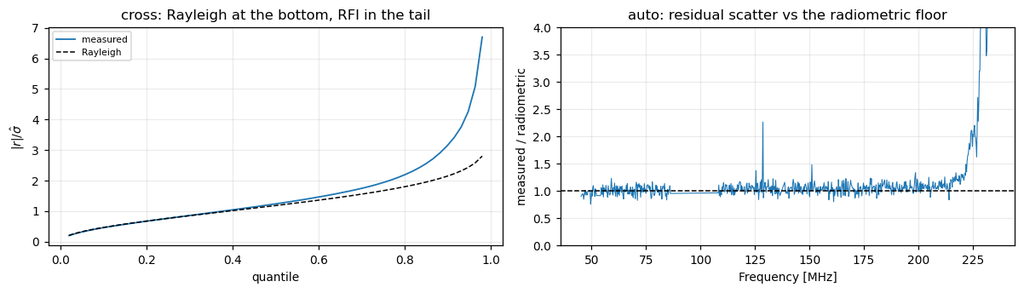

The cross floor does not behave as well. The bottom of the distribution is Rayleigh to ~1%, which is why $\hat\sigma$ is fitted on the 25th percentile and not the median — but the fitted value sits a factor ~2 above the radiometric prediction. Either the cross achieves ~20% of ideal sensitivity or there is a common-mode floor between the two antennas. **Unresolved**, and it means the coherence z is a calibrated *relative* statistic, not an absolute one.

## Stage 2 — a priori bands

Known emitters masked *before* any statistic is computed, so they cannot contaminate a fitted scale or drag the continuum fit. FM, ORBCOMM, the two clock harmonics, and (when asked) the self-comb teeth ± 1 channel.

These are still reported as flagged. Excluded from the statistics, not from the product.

```
a priori channels: 92 of 1024 (9.0% of the full axis, 11.8% of the analysis band)
   FM         88.0- 108.0 MHz    82 channels
   ORBCOMM   136.5- 138.5 MHz     8 channels
   clock    ['125.000', '187.500'] MHz
```

```
self-comb era, teeth +/-1 channel: a priori covers 44.7% of the analysis band
```

## Stage 3 — transient, model-free on the raw autos

Per channel along time: a running median (width 9) removes slow gain drift, and what is left is compared to $\max(P/\sqrt N,\ \mathrm{MAD})$, one-sided. No model, no cross, and it runs over the **full** axis — channels outside 45–235 MHz are where the cleanest instrumental diagnostics live.

Channels carrying essentially no power are not testable at all (below ~25 MHz the median is 0–0.5 counts, so every scale estimate collapses); `min_counts` excludes them.

[output not shown]

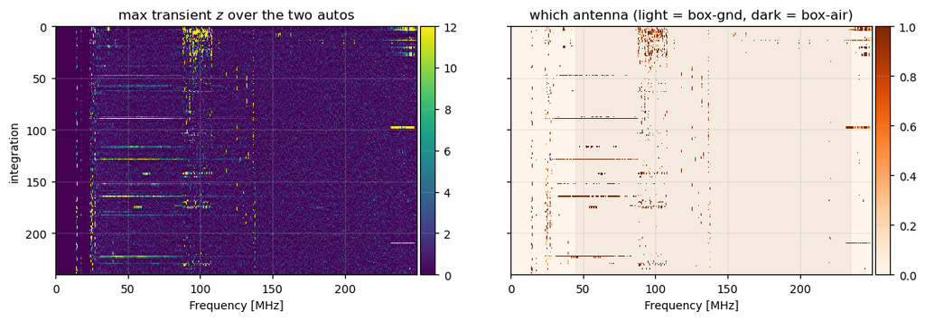

**Assessment.** Working, and it is the stage that covers what the cross cannot: it needs neither a partner antenna nor a model, so it is the only detector that functions where the cross is quantisation-limited.

Two things it finds on this file that nothing else would. A set of simultaneous single-integration tones whose channel indices are exactly 49 and 207 mod 256 — two families 62.5 MHz ($f_s/8$) apart, mirror images about the grid, i.e. an aliased clock artifact rather than sky RFI. And broadband excursions confined to **one antenna**, which the coherence stage is blind to by construction.

## Stages 4–6 — whole-integration tests

Three statistics that condemn an entire integration rather than a pixel, because a contaminated row cannot be partially trusted.

- **broadband** (bit 4): more than `broadband_frac` of the band tripped the transient test at once. A few-percent excess across hundreds of channels leaves most of them individually below threshold, and letting those constrain the continuum is how one bad row reaches every other row's residual.
- **gross power** (bit 5): the median over 236–249 MHz, where the bandpass has rolled off ~3 decades but a broadband transient still lands. Median, not mean, because that band has a narrow emitter in it.
- **meteor** (bit 6): FM and DTV rising together, each normalised by a reference continuum (108–136, 155–174, 216–235 MHz) so common gain drift divides out.

```
broadband      4 integrations  [ 89 128 164 222]
gross power    2 integrations  [ 97 209]
meteor         2 integrations  [13 16]
```

```
in-band transient fraction: median 0.0039, p99 0.174, max 0.238
```

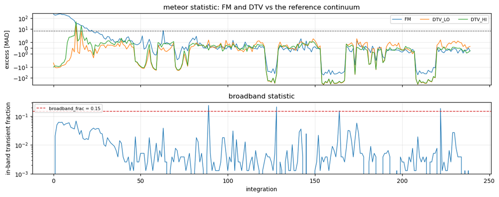

**Assessment.** The broadband threshold is not delicate — the in-band transient fraction has median 0.004 and p99 0.17, so 0.15 selects a handful of rows and 0.25 selects none. That is the behaviour you want from a morphological cut.

The meteor statistic is the weakest of the three and **fires on things it was not built for**: the single-integration clock-comb events trip it, because they are not propagation but they do lift the transmitter bands relative to the reference. It should probably require the FM/DTV rise to occur *without* a simultaneous transient elsewhere. Not fixed.

## Stage 7 — coherence

$|V_{ab}|/\sqrt{P_aP_b}$: the fraction of the two autos' amplitude that is actually correlated between the antennas. Receiver noise is independent and averages down in the cross; a common interferer does not. It is also naturally normalised — bandpass, reflection ripple and the accumulator change all divide out — so one threshold means the same thing across the band.

$\hat\sigma$ is fitted **per channel** on a low quantile. That absorbs a frequency-dependent common-mode floor, at a price paid in stage 8.

```
coherence-flagged pixels: 0.0077 of the full axis

highest median coherence in band:
     88.135 MHz   C = 0.143  FM
     91.797 MHz   C = 0.205  FM
     92.773 MHz   C = 0.118  FM
     93.262 MHz   C = 0.108  FM
     94.482 MHz   C = 0.798  FM
     97.656 MHz   C = 0.170  FM
    100.586 MHz   C = 0.115  FM
    101.074 MHz   C = 0.240  FM
    101.807 MHz   C = 0.123  FM
    125.000 MHz   C = 0.077  <- clock harmonic
    137.695 MHz   C = 0.689  ORBCOMM
    137.939 MHz   C = 0.103  ORBCOMM
```

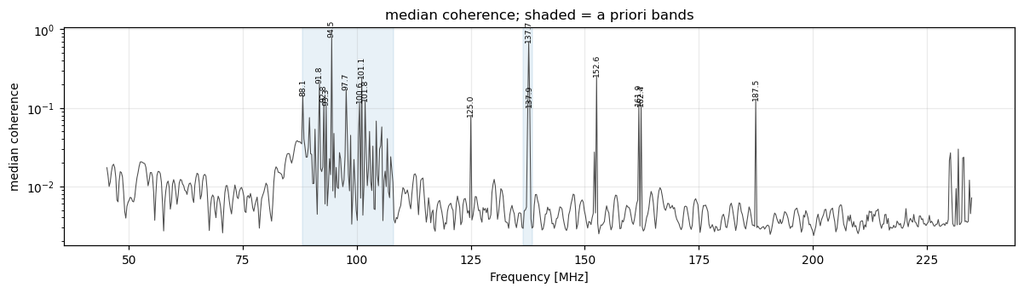

Two failure modes, both real:

1. **Quantisation.** In phase A the cross has 21–38% of in-band samples with $|V|$ *exactly* zero, so $\hat\sigma$ collapses and the stage reports a clean sky. `quantisation_ok()` refuses those files; roughly the first two campaign days have no coherence path at all.
2. **Self-suppression.** Because $\hat\sigma$ is fitted per channel, a channel contaminated at *every* sample simply gets a bigger $\hat\sigma$ and stops being an outlier against itself. In the self-comb era the whole band is busy enough that the stage goes quiet where it should be loudest.

## Stages 8–9 — persistent lines and occupancy

Stage 7 cannot see a tone that is on at every sample. Along frequency it is obvious: that channel's fitted floor stands above its neighbours'. Stage 8 median-filters $\hat\sigma(\nu)$ and flags the channels that stand proud.

Stage 9 promotes any channel flagged in more than `occ_frac` of its valid samples to a whole-channel kill — a ragged partial mask on a mostly-on emitter is worse than useless, because downstream averaging then sees a biased subset.

```
persistent lines: 58 channels   occupancy kills: 61
overlap: 58

line channels (MHz):
   [46.63, 52.49, 52.73, 52.98, 53.22, 53.47, 86.43, 86.67, 86.91, 87.16, 87.4, 87.65, 87.89, 88.13, 88.38, 89.6, 90.82, 91.55, 91.8, 92.77, 93.26, 94.48, 94.97, 96.19, 97.41, 97.66, 97.9, 98.63, 99.37, 100.34, 100.59, 101.07, 101.81, 102.78, 103.52, 104.25, 104.98, 105.22, 105.47, 106.69, 107.42, 1…
```

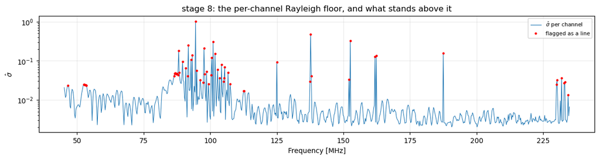

**Assessment.** This is the piece B16 has no equivalent of, and it is doing the work: the line channels are the FM carriers, ORBCOMM, the clock harmonics, 152.6, 161.9/162.4 and a block near 230–234 MHz — narrow clusters, not smeared.

152.6 and 161.9/162.4 are real, persistent and **unattributed**. 152.6 sits outside `detectors.BAND_FAN = (148, 152)`, so calling it the box fan would be an identification the data does not support.

## Stage 10 — second pass: re-deciding after the DPSS fit

A flag raised before the continuum is modelled is provisional. With a 40 ns DPSS model fitted on what survived stage 9, the auto can be asked an independent question — does this sample still stand above the *radiometric* noise? — and the answer is allowed to be no.

`z_coh` alone does not carry a flag through, or the second pass would be decoration:

| condition | outcome |
| --- | --- |
| $z_{\rm res} > t_{hi}$ | flag — auto evidence |
| $z_{\rm coh} > t_{lo}$ and $z_{\rm res} > t_{lo}$ | flag — corroborated |
| $z_{\rm coh} > t_{hi}$, $z_{\rm res} \le t_{lo}$ | **retract** |

"Correlated" is not the same claim as "interference"; only the auto settles it.

```
dpss_ok        True
second pass    applied
retracted      1482 pixels
promoted       15285 pixels
model inflation (median) 1.05

|z_res| > 6 among fit-constraining pixels: 0.0070
worst remaining channels:
    146.484 MHz   occ=0.89   median z=   -7.2
    145.996 MHz   occ=0.86   median z=   -7.0
    146.240 MHz   occ=0.85   median z=   -7.4
    145.752 MHz   occ=0.74   median z=   -6.6
    146.729 MHz   occ=0.65   median z=   -6.4
    232.422 MHz   occ=0.28   median z=   -5.4
```

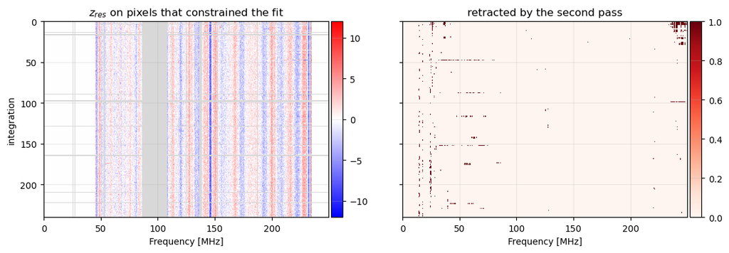

**Assessment.** Trustworthy only where the continuum model fits. `model_inflation` is the diagnostic: near 1 the auto test is calibrated and promotes modestly; where the 40 ns model cannot follow the data the residual is full of *model error* rather than noise and the test over-promotes. §12 shows that directly across campaign conditions.

It can also decline to run — `hera_filters` returns an all-zero model rather than raising when a wide contiguous block is zero-weighted at a band edge, and `dpss_ok` catches that.

## 11. The composite mask

```
 bit  name          full axis   in band
----------------------------------------
   0  off_sky          0.0000    0.0000
   1  overflow         0.0000    0.0000
   2  a_priori         0.0898    0.1183
   3  transient        0.0121    0.0127
   4  broadband        0.0167    0.0167
   5  gross_power      0.0083    0.0083
   6  meteor           0.0083    0.0083
   7  coherent         0.0077    0.0082
   8  line             0.0566    0.0746
   9  occupancy        0.0596    0.0746
  11  residual         0.0082    0.0108
  10  retracted        0.0060    0.0016
----------------------------------------
      any RFI bit      0.1548    0.1895
      unusable         0.0000    0.0000
      clean            0.8391    0.8088
```

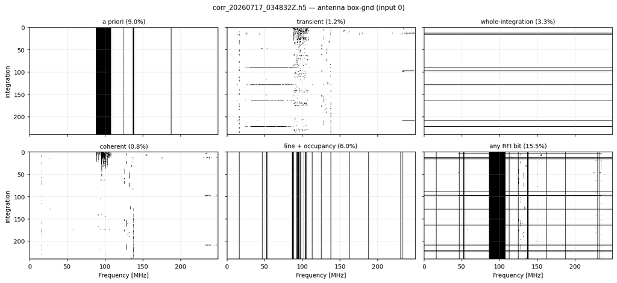

```
does the excess reach beyond a flagged channel?
offset   median z (channel)   median z (time)
    0        (core)            (core)
    1          1.12              0.89
    2          1.08              0.89
    3          1.08              0.89
    4          1.08              0.89
    5          1.01              0.89
    6          1.00              0.89
    7          1.02              0.89
    8          1.03              0.89
```

Flat at $z \approx 1$ from offset 1 on both axes — the immediate neighbours of a flagged channel, and the integrations either side of a flagged sample, are already at the noise floor. There is no shoulder to catch, which is why dilation defaults to 0.

## 11b. DPSS on the masked data — residual with and without the mask

The point of the whole exercise: fit a continuum to data the mask has cleaned, and look at what is left. Shown on the **sky antenna** (box-air) for three files that differ in how busy they are.

Each row is one file: the raw auto, the residual `data - model` with **no** mask applied, and the same residual with the mask applied. The middle panel is what the continuum fit has to cope with; the right panel is what a downstream analysis would actually see.

```
comb off        input 4  dpss_ok=True  infl=1.17  masked=0.199
```

```
event window    input 4  dpss_ok=False  infl=nan  masked=0.297
```

```
self-comb on    input 4  dpss_ok=True  infl=4.17  masked=0.486
```

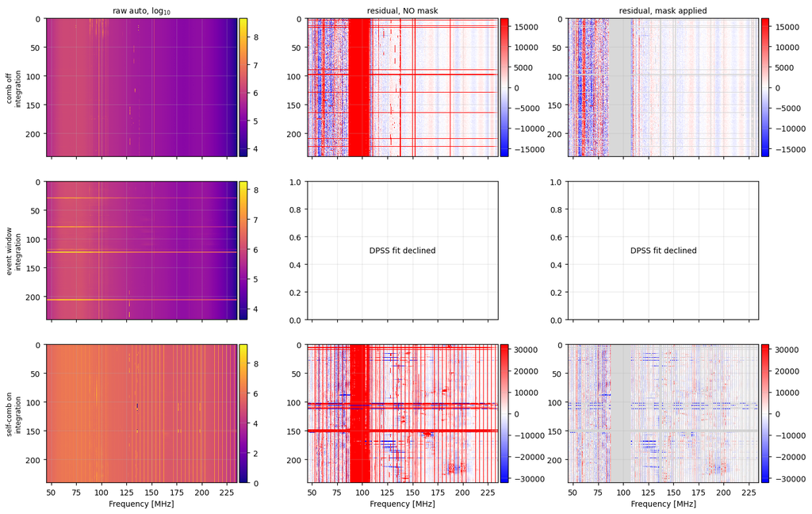

```
file              rms resid  rms masked  |z|>6 all  |z|>6 kept
--------------------------------------------------------------
comb off           1.66e+06        4269     0.1836      0.0125
event window     DPSS fit declined
self-comb on      1.399e+07   1.758e+05     0.3323      0.0153
```

**Assessment.** The middle and right panels are the before/after that matters. Unmasked, the residual is dominated by the lines the fit deliberately did not absorb — they are still in `data - model` because the model refused them, which is the correct behaviour and the reason the panel looks so busy. With the mask applied, what remains is the noise the continuum could not follow.

The `rms masked` column is the honest summary: on the comb-off file it drops by roughly two orders of magnitude relative to the unmasked residual. On the event file the DPSS fit declines to run (`dpss_ok` False) because pass 1 zero-weights a wide contiguous block, so there is no residual to show — that is the guard working, not a gap in the figure.

Colour scales are set from the *masked* residual and shared across both panels, so the right-hand panel is not made to look empty by its own normalisation.

## 12. The same stages across campaign conditions

One file per condition: both wiring phases, both accumulator lengths, comb on and off, a labelled event window.

```
condition          sw? xquant  infl   fit   apri  trans    coh  resid   line  anyRFI   retr
-------------------------------------------------------------------------------------------
A start             NO  False  0.44  True  0.118  0.014  0.000  0.014  0.000   0.140  0.001
A short acc         NO  False  0.77  True  0.118  0.000  0.000  0.000  0.000   0.118  0.000
B (keys 3/5)       yes   True  1.75  True  0.118  0.007  0.002  0.120  0.102   0.321  0.000
C event window     yes   True   nan False  0.118  0.080  0.050  0.000  0.122   0.297  0.000
C comb off         yes   True  1.05  True  0.118  0.013  0.008  0.011  0.075   0.190  0.002
C self-comb on     yes   True  3.48  True  0.447  0.039  0.008  0.012  0.116   0.477  0.009
```

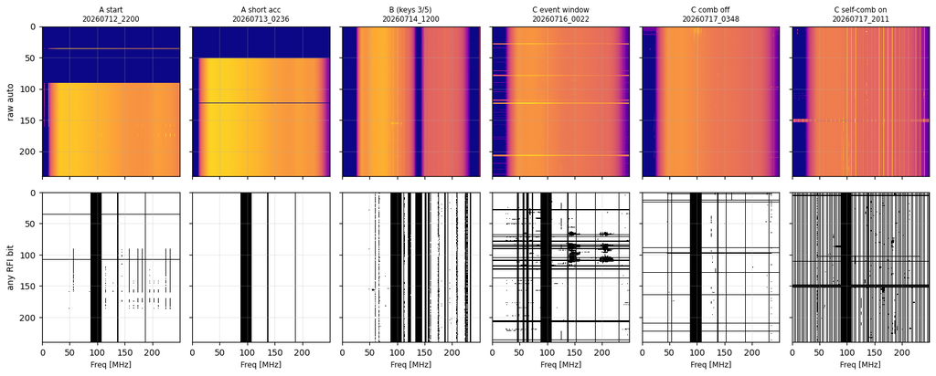

## 13. Where this stands

Known limitations, in the order I would fix them:

1. **The second pass is only trustworthy where `model_inflation` ≈ 1.** In phase B and the self-comb era it over-promotes. Fixing that means a continuum model that fits those eras, not a different threshold.
2. **No completeness measurement.** `flagging/validate.py` has the harness — labelled-window recall, false-positive rate on quiet data, an injection curve giving the 50%/90% detection thresholds — and none of it has been pointed at this. Everything above is descriptive; there is no signal-loss number.
3. **Stage 7 self-suppresses on persistently contaminated channels**, because $\hat\sigma$ is fitted per channel. Stage 8 covers the steady case; a channel contaminated most-but-not-all of the time is covered by neither.
4. **The meteor statistic fires on non-propagation events.** It should require the FM/DTV rise to happen without a simultaneous transient elsewhere.
5. **Output is a union across antennas.** v0's product is per-input, and a box-air-only event currently masks box-gnd data too. Conservative, but it discards good data on a clean antenna — a decision to make deliberately before this is written in the `flags/<version>/` schema.
6. **The cross noise floor is a factor ~2 above radiometric and unexplained.**